# About me

### Background

Hi there! My name is Carlos, I am a second-year MHS student in the Department of Epidemiology at the Bloomberg School of Public Health. I’m currently working toward getting a degree in epidemiology (epi) with a concentration in infectious disease epi. I completed my undergraduate studies at the University of Florida in Gainesville, FL, where I received a Bachelor of Science in Biochemistry. Throughout my undergrad experience I worked in a lab that primarily focused on tropical infectious diseases - where I was able to do some work on dengue, and more recently COVID-19. I’m interested in preventative interventions, and I’m particularly interested in the deliverance of vaccines and their direct/indirect impacts on community health. My research at Hopkins revolves around important aspects of vaccine science and policy, as I’m attempting to link the indirect benefits of pneumonia vaccinations with the downstream reduction of events that reduce functional mobility among the elderly (e.g., falls, fractures, re-hospitalization, etc.). I’m also passionate about maternal and neonatal health!

### Fun facts

Some non-academic factors about me: 1. I love coffee, and really appreciate the aesthetic of coffee shops, so I’ve made it a mission to explore as many coffee shops in Baltimore as possible! 2. I’m a proud owner of a snake plant that is currently **thriving**, and I’m in the market to buy more plants soon (maybe an aloe vera plant?) 3. I’m an avid basketball fan (Let’s go Heat!) 4. I like to cook/bake 5. I once owned two finches and ended up with a family of 12!

### Twitter account that YOU MUST follow + random thought

Lots of quality content here.

WeRateDogs (@dog_rates) https://twitter.com/dog_rates?ref_src=twsrc%5Egoogle%7Ctwcamp%5Eserp%7Ctwgr%5Eauthor

Thoughts of Dog (@dog_feelings) https://twitter.com/dog_feelings

I love that capybaras can befriend many other animals, so wholesome!

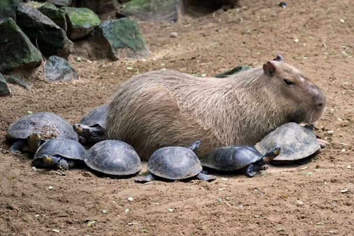

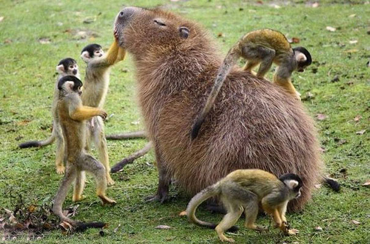